# U.S. Prison System Discrimination

Daphne He

Autumn 2022

## Abstract

The US prison and jail system continues to reinforce biased practices that continue to oppress Black males more than any other demographic. This would be made more clear by several trends comparing the Black prison and jail population with other groups of people. There is also the clear increase in incarceration rate in general that’s concerning.

## Introduction (Section 1)

In this assignment, I will be finding patterns and trends in the data that suggest inequalities and biases in the the American prison and jail system. The data set I’m using provides info on the race, gender, age group, location, year, etc. It will allow me to compare the demographic of inmates in different locations at various points of time. There is no denying that Black people have historically been oppressed in American society and the American prison system continues to reinforce this systematic oppression by incarcerating Black males at much higher rates than other groups. From Data Feminism, we know that power is unequally distributed in our world. Current practices reinforce the power wielded disproportionately by the elite. I plan to use data to expose and challenges the fairness of the American jail and prison system over the last five decades. The direct stakeholders are the people in the American prison system and the everyone who’s job is affected by the American prison and jail system. The indirect stakeholders are everyone who is subject to the law. I will answer questions like “Which demographic is most likely to be incarcerated?” and “How has the prison population changed over time?”

## Data Summary (Section 2)

The Black incarcerated population count average for ages 15-64 in 2018 was 9,186. The Black incarcerated population count average for ages 15-64 in 2000 was 7,309. This shows that the number of Black people incarcerated only continues to grow, further proving that the system continues to reinforce itself and oppress young Black people. For comparison, the White incarcerated population count average for ages 15-64 in 2018 was 41,095. Considering that Black people only make up around 13% of the US population, the proportions of Black people in jail compared to that of White people only further prove the biases of the American prison and jail system. There doesn’t seem to be any change. In fact, the incarceration of Black people ages 15-64 was highest in New York County. It’s about time politicians looked into why this is the case.

## Growth of the U.S. Prison Population (Section 3)

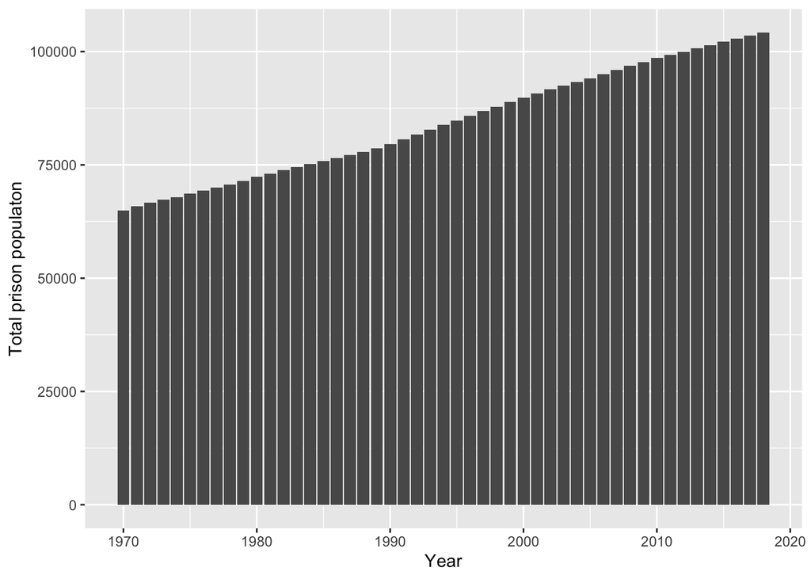

In the chart, we can see that there is a general increase in the U.S. prison population from 1970 to 2018. This shows that there seems to changes over time that affect the amount of people being sentenced to prison. The question is: Is the increase in prison population due to there being more crimes committed or due to changes in policy and laws sentencing people?

## Growth of Prison Population by State (Section 4)

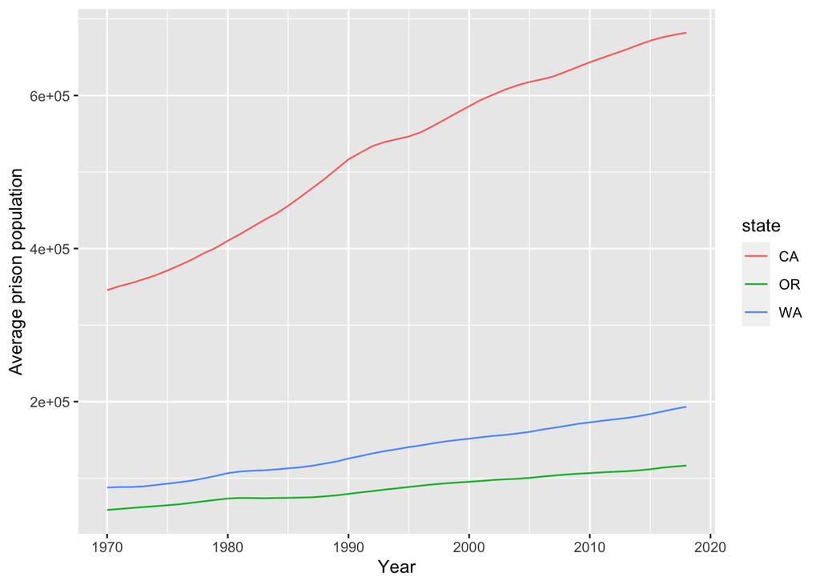

*Caption:* The lines chart shows the change in average prison population for Washington, Oregon, and California.

The jail population in California appears to be growing at a much quicker rate than that of Washington and Oregon. It also shows that California had a much larger jail population in 1970 than Washington and Oregon. Washington’s incarceration rate is slightly higher than Oregon’s. Regardless which state, the prison jail population is growing. The question is: Why is California’s incarceration rate so much higher than Washington and Oregon’s?

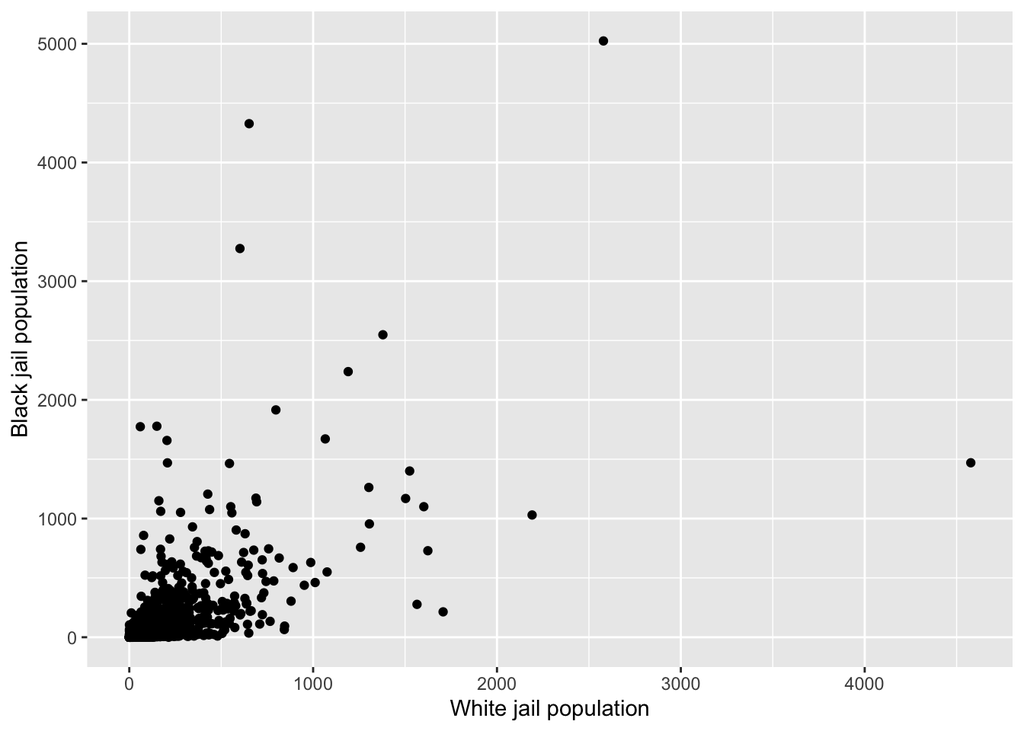

*Caption:* The scatter plot shows the Black prison population vs the White prison population.

Question: Where are Black people being incarcerated at higher rates than White people? What do all theses places have in common? The scatter plot shows that most of the time there are more White people, but the proportion in comparison to how many White people are in the U.S. versus Black people show that Black people have much higher incarceration rates. There are a few outliers.

## Incarceration rate by state choropleth map (Section 6)

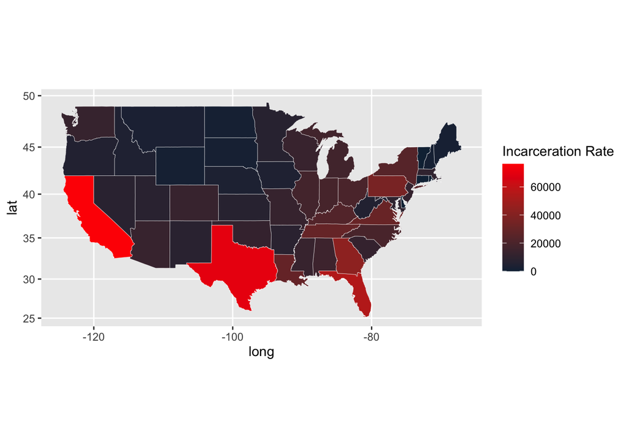

*Caption:* A map displaying the incarceration rates by state.

Question: Why do Texas and California have such high incarceration rates? The choropleth map shows that California and Texas have the highest incarceration rates because they are the brightest red. This is probably because they have larger populations and also have laws and policies that keep people in prison for longer or for lesser crimes.